# Practical Machine Learning Course Project

John Lin

## Introduction

Research on activity recognition often focuses on predicting “which” activity was performed, but rarely on “how well” an activity was performed. In this project, we will use data from accelerometers to predict the manner in which a weight lifting exercise was performed.

## Dataset

Data from accelerometers on the belt, forearm, arm, and dumbell of 6 participants were collected. Participants performed one set of 10 repetitions of the Unilateral Dumbbell Biceps Curl in five different manners (Classes A to E). Class A corresponds to the “correct” execution of the exercise, whereas the other 4 classes correspond to common mistakes. More information about the dataset can be found [here](http://web.archive.org/web/20161224072740/http:/groupware.les.inf.puc-rio.br/har#wle_paper_section).

First, read in the dataset.

```r
data.orig <- read.csv("https://d396qusza40orc.cloudfront.net/predmachlearn/pml-training.csv")
```

Let’s look at the dimensions of the dataset.

```r
dim(data.orig)
```

```
## [1] 19622   160
```

The dataset consists of 19622 time windows and 160 variables.

Let’s look at the names of the variables.

```r
names(data.orig)[1:15]
```

```
##  [1] "X"                    "user_name"            "raw_timestamp_part_1"
##  [4] "raw_timestamp_part_2" "cvtd_timestamp"       "new_window"
##  [7] "num_window"           "roll_belt"            "pitch_belt"
## [10] "yaw_belt"             "total_accel_belt"     "kurtosis_roll_belt"
## [13] "kurtosis_picth_belt"  "kurtosis_yaw_belt"    "skewness_roll_belt"
```

The first 7 columns include information about the subject and the time window. The next columns include features that we are interested in, such as the mean, variance, and standard deviation from accelerator readings. The last column `classe` is the variable we are trying to predict.

Remove the first few columns that include information about the subject and the time window. Convert the remaining feature columns to numeric variables. Remove feature columns that have > 90% NA values.

```r
# Remove columns about subject and time window
data <- data.orig[,-(1:7)]
# Convert feature columns to numeric
data[,-dim(data)[2]] <- apply(data[,-dim(data)[2]], 2, as.numeric)
# Remove feature columns with > 90% NAs
row.index <- apply(apply(data, 2, is.na), 2, sum) < 0.9 * dim(data)[1]
data <- data[,row.index]
```

Split the dataset into train, test, and validation sets.

```r
library(caret)
set.seed(41705)
inTrain <- createDataPartition(y = data$classe, p = 0.6, list = FALSE)
data.train <- data[inTrain,]
data.not.train <- data[-inTrain,]
inTest <- createDataPartition(y = data.not.train$classe, p = 0.5, list = FALSE)
data.test <- data.not.train[inTest,]
data.validation <- data.not.train[-inTest,]
```

## Model

Let’s fit a random forest model. We used a random forest model because random forests usually have high accuracy.

We also performed 10-fold cross validation to estimate the out of sample error.

```r
## Configure parallel processing
library(parallel)
library(doParallel)
cluster <- makeCluster(detectCores() - 1)
registerDoParallel(cluster)

## Configure trainControl object
fitControl <- trainControl(
  method = "cv",
  number = 10,
  allowParallel = TRUE
)

## Develop training model
fit <- train(classe ~ ., data = data.train, method = "rf", trControl = fitControl)

## Deregister parallel processing cluster
stopCluster(cluster)
registerDoSEQ()
```

## Results

Let’s look at our final random forest model. We’ll also plot a figure comparing the accuracy of 3 random forest models with different numbers of predictors. We’ll then calculate the variable importance for the top 20 predictors.

```r
library(randomForest)
fit$finalModel
```

```
##
## Call:
##  randomForest(x = x, y = y, mtry = param$mtry)
##                Type of random forest: classification
##                      Number of trees: 500
## No. of variables tried at each split: 27
##
##         OOB estimate of  error rate: 1.04%
## Confusion matrix:
##      A    B    C    D    E class.error
## A 3340    7    0    0    1 0.002389486
## B   21 2246   12    0    0 0.014480035
## C    0   18 2029    7    0 0.012171373
## D    0    0   35 1892    3 0.019689119
## E    0    1    6   11 2147 0.008314088
```

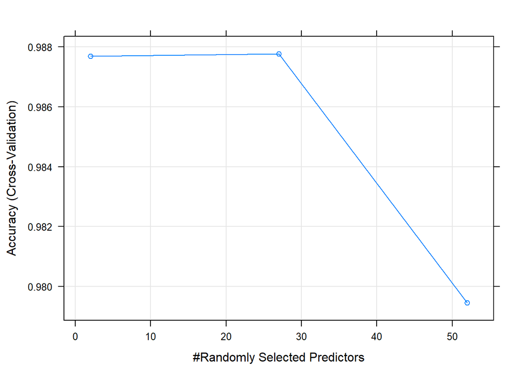

```r
plot(fit, log = "y")
```

```r
varImp(fit, scale = FALSE)
```

```
## rf variable importance
##
##   only 20 most important variables shown (out of 52)
##
##                      Overall
## roll_belt             1247.1
## pitch_forearm          729.7
## yaw_belt               631.4
## magnet_dumbbell_y      555.1
## roll_forearm           545.2
## pitch_belt             533.1
## magnet_dumbbell_z      510.5
## accel_dumbbell_y       263.8
## accel_forearm_x        232.3
## magnet_dumbbell_x      219.6
## roll_dumbbell          217.9
## total_accel_dumbbell   197.3
## magnet_forearm_z       192.8
## accel_belt_z           191.5
## magnet_belt_z          190.2
## accel_dumbbell_z       187.2
## magnet_belt_y          171.7
## yaw_arm                155.5
## gyros_belt_z           140.1
## magnet_belt_x          137.3
```

The model includes 500 classification trees with 27 features in each tree. The accuracy of our model on the training set is 99%. The estimated out of sample error from cross validation is 1%. Top predictors include `roll_belt`, `pitch_forearm`, and `yaw_belt`. The sensitivity and specificity for each class appears to be similar.

Let’s look at the performance of our model on our testing set to see if the model is overfitting.

```r
pred <- predict(fit, newdata = data.test)
confusionMatrix(pred, data.test$classe)
```

```
## Confusion Matrix and Statistics
##
##           Reference
## Prediction    A    B    C    D    E
##          A 1115    9    0    0    0
##          B    1  747    5    1    0
##          C    0    3  678   13    1
##          D    0    0    1  629    4
##          E    0    0    0    0  716
##
## Overall Statistics
##
##                Accuracy : 0.9903
##                  95% CI : (0.9867, 0.9931)
##     No Information Rate : 0.2845
##     P-Value [Acc > NIR] : < 2.2e-16
##
##                   Kappa : 0.9877
##
##  Mcnemar's Test P-Value : NA
##
## Statistics by Class:
##
##                      Class: A Class: B Class: C Class: D Class: E
## Sensitivity            0.9991   0.9842   0.9912   0.9782   0.9931
## Specificity            0.9968   0.9978   0.9948   0.9985   1.0000
## Pos Pred Value         0.9920   0.9907   0.9755   0.9921   1.0000
## Neg Pred Value         0.9996   0.9962   0.9981   0.9957   0.9984
## Prevalence             0.2845   0.1935   0.1744   0.1639   0.1838
## Detection Rate         0.2842   0.1904   0.1728   0.1603   0.1825
## Detection Prevalence   0.2865   0.1922   0.1772   0.1616   0.1825
## Balanced Accuracy      0.9979   0.9910   0.9930   0.9884   0.9965
```

The accuracy of our model in the testing set is 99%, which is similar to the accuracy in the training set. Therefore, the model is not overfitting. For our purposes, 99% accuracy is “good” enough, and we will not be refining the model further.

Lastly, let’s look at the performance of our model on our validation set.

```r
pred <- predict(fit, newdata = data.validation)
confusionMatrix(pred, data.validation$classe)
```

```
## Confusion Matrix and Statistics
##
##           Reference
## Prediction    A    B    C    D    E
##          A 1116   10    0    0    0
##          B    0  745    6    0    1
##          C    0    3  676    6    2
##          D    0    1    2  636    1
##          E    0    0    0    1  717
##
## Overall Statistics
##
##                Accuracy : 0.9916
##                  95% CI : (0.9882, 0.9942)
##     No Information Rate : 0.2845
##     P-Value [Acc > NIR] : < 2.2e-16
##
##                   Kappa : 0.9894
##
##  Mcnemar's Test P-Value : NA
##
## Statistics by Class:
##
##                      Class: A Class: B Class: C Class: D Class: E
## Sensitivity            1.0000   0.9816   0.9883   0.9891   0.9945
## Specificity            0.9964   0.9978   0.9966   0.9988   0.9997
## Pos Pred Value         0.9911   0.9907   0.9840   0.9938   0.9986
## Neg Pred Value         1.0000   0.9956   0.9975   0.9979   0.9988
## Prevalence             0.2845   0.1935   0.1744   0.1639   0.1838
## Detection Rate         0.2845   0.1899   0.1723   0.1621   0.1828
## Detection Prevalence   0.2870   0.1917   0.1751   0.1631   0.1830
## Balanced Accuracy      0.9982   0.9897   0.9925   0.9939   0.9971
```

The accuracy of our model on our validation set is 99%.

## Conclusion

We have built a random forest model with 10 fold cross validation. Our final model consists of 500 classification trees with 27 predictors in each tree. The accuracy of our model on the validation set is 99%. The estimated out of sample error is 1%.

## References

Velloso, E.; Bulling, A.; Gellersen, H.; Ugulino, W.; Fuks, H. Qualitative Activity Recognition of Weight Lifting Exercises. Proceedings of 4th International Conference in Cooperation with SIGCHI (Augmented Human ’13) . Stuttgart, Germany: ACM SIGCHI, 2013.